# Day 11: Define Augmentation Procedures

**Selected Augmentation Procedures:**

- **Brightness and Contrast Adjustment**  
  *Description:* Modifies the overall intensity and the difference between light and dark areas in the image. This simulates varying lighting conditions.
- **Gaussian Noise Addition**  
  *Description:* Adds random noise following a Gaussian distribution to pixel values. This simulates sensor noise, which is common in low-light environments or with lower quality cameras.

```
--- Testing Augmentations on a Dummy Image ---
```

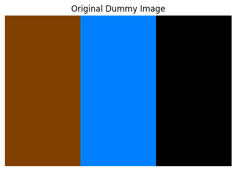

```
Applied Brightness/Contrast: alpha=1.0, beta=50
```

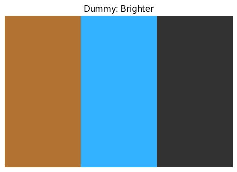

```
Applied Brightness/Contrast: alpha=1.5, beta=0
```

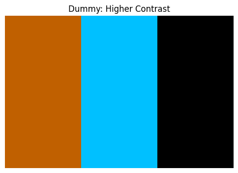

```
Added Gaussian Noise: mean=0, std_dev=25
```

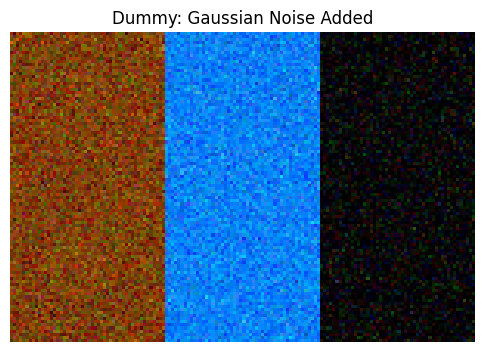

```python
from helper_functions_3 import display_image
import cv2
import numpy as np


def augment_brightness_contrast(image, alpha=1.0, beta=0):
    """
    Adjusts image brightness and contrast.
    alpha: Contrast control (1.0 = no change)
    beta: Brightness control (0 = no change)
    Formula: new_image = alpha * original_image + beta
    """
    # Apply the transformation using cv2.convertScaleAbs
    # This scales, calculates absolute values, and converts back to uint8
    adjusted = cv2.convertScaleAbs(image, alpha=alpha, beta=beta)
    print(f"Applied Brightness/Contrast: alpha={alpha}, beta={beta}")
    return adjusted


def augment_gaussian_noise(image, mean=0, std_dev=10):
    """
    Adds Gaussian noise to an image.
    mean: Mean of the Gaussian distribution.
    std_dev: Standard deviation of the Gaussian distribution (controls noise intensity).
    """
    # Generate Gaussian noise
    row, col, ch = image.shape
    gauss_noise = np.random.normal(mean, std_dev, (row, col, ch))

    # Add noise to the image. Need to handle potential dtype issues and clipping.
    noisy_image_float = image.astype(np.float32) + gauss_noise
    # Clip values to stay within the valid range [0, 255]
    noisy_image_clipped = np.clip(noisy_image_float, 0, 255)
    # Convert back to original dtype (usually uint8)
    noisy_image = noisy_image_clipped.astype(image.dtype)
    print(f"Added Gaussian Noise: mean={mean}, std_dev={std_dev}")
    return noisy_image


# --- Test with a sample/dummy image ---
print("\n--- Testing Augmentations on a Dummy Image ---")
# Create a simple dummy image (e.g., a colored rectangle)
dummy_image = np.zeros((100, 150, 3), dtype=np.uint8)
dummy_image[:, 50:100] = [255, 128, 0]  # Orange color in BGR
dummy_image[:, 0:50] = [0, 64, 128]  # Brownish color
display_image(dummy_image, "Original Dummy Image")

# Test Brightness/Contrast
dummy_brighter = augment_brightness_contrast(
    dummy_image, alpha=1.0, beta=50
)  # Increase brightness
display_image(dummy_brighter, "Dummy: Brighter")
dummy_contrast = augment_brightness_contrast(
    dummy_image, alpha=1.5, beta=0
)  # Increase contrast
display_image(dummy_contrast, "Dummy: Higher Contrast")

# Test Gaussian Noise
dummy_noisy = augment_gaussian_noise(dummy_image, mean=0, std_dev=25)  # Add noise
display_image(dummy_noisy, "Dummy: Gaussian Noise Added")
```

# Day 12: Define Augmentation Use Case

### Chosen Use Case: *Improving Robustness of Automated Polish Landmark Recognition*

#### **Problem Statement**

Developing automated systems (e.g., for tourism apps, cultural heritage documentation, educational tools) to recognize specific Polish landmarks (such as the Palace of Culture and Science, Wawel Castle, or the Unicorn in Łódź) from images is highly desirable.  
However, models trained only on high-quality, well-lit "studio" or postcard images often fail in real-world scenarios (tourist photos, street views, varying weather conditions) due to significant variations in:

- **Lighting conditions** (brightness, contrast)
- **Camera sensor noise**

This lack of robustness limits the practical applicability of such recognition systems.

#### **Practical Use Case & Aim**

The aim is to use image augmentation to create a more diverse training dataset for a hypothetical landmark recognition model.  
By synthetically generating variations of existing images, we want to simulate the conditions the model might encounter in reality.

#### **Objectives of the Experiments**

- Apply **brightness/contrast adjustments** and **Gaussian noise addition** to images of Polish landmarks.
- Simulate realistic variations in lighting and sensor quality typically encountered outside of ideal conditions (e.g., cloudy days, night shots, smartphone cameras).
- Prepare these augmented images as examples that could be used to train a more robust machine learning model capable of recognizing Polish landmarks across different environments.
- Quantitatively measure the introduced changes using a suitable metric.

#### **Why These Augmentations?**

- **Brightness/Contrast Adjustment:**  
  Directly simulates variations in ambient light (overcast vs. sunny days, dusk vs. noon) and camera exposure settings.  
  Crucial for models to recognize landmarks regardless of how bright or contrasted the image is.
- **Gaussian Noise:**  
  Mimics electronic noise from camera sensors, which is more prevalent in lower light conditions or with lower-quality cameras (like phones).  
  Helps the model become less sensitive to minor imperfections and noise textures.

```python
# Day 12: Load Polish Food Images

image_paths = {
    "Unicorn 1": "./Unicorn_1.jpeg",
    "Unicorn 2": "./Unicorn_2.jpeg",
    "PKIN": "./PKIN.jpg",
}

image_attributions = {
    "Unicorn 1": "Source: https://lodz.travel/en/tourism/what-to-see/piotrkowska-street/unicorn-stable-and-unicorn-statue/",
    "Unicorn 2": "Source: https://depositphotos.com/fr/editorial/unicorn-city-lodz-lodz-poland-june-2019-monumental-unicorn-sculpture-280045220.html ",
    "PKIN": "Source: https://en.wikipedia.org/wiki/File:Warszawa_Pa%C5%82ac_Kultury_i_Nauki_2009.jpg",
}

original_images = {}
print("Loading images...")

for name, path in image_paths.items():
    try:
        image = cv2.imread(path)
        if image is None:
            raise ValueError("Image decoding failed.")
        original_images[name] = image
        print(f"Successfully loaded {name} image. {image_attributions[name]}")
        display_image(image, f"Original Image: {name}")
    except requests.exceptions.RequestException as e:
        print(f"Error fetching {name} image: {e}")
    except Exception as e:
        print(f"Error processing {name} image: {e}")

if len(original_images) != len(image_paths):
    print("Warning: Not all images were loaded successfully.")
```

[output not shown]